# Table of Contents

# Introduction:

This project is a part of IBM Data Science Professional Certificate Course that I am pursuing on Coursera. This project aims to answer to the business problem: "Can a driver predict the severity of a future accident by observing a number of conditions such as road condition, weather condition, visibility condition etc.".

Car accident has become a very serious problem in Seattle. It has become essential to develop a model which can predict the severity of a car accident in terms of human fatality, physical injury, property damage, traffic delay etc and thereby alert the drivers about the accidents ahead of time.

**Stakeholders:** The reduction in severity of accidents can be beneficial to the Public Development Authority of Seattle which works towards improving those road factors and the car drivers themselves who may take precaution to reduce the severity of accidents.

# Data Unserstanding

## Data Collection

For this project, we don't need to go through web scraping as we already have a data set provided as a csv file which can be found [here](https://s3.us.cloud-object-storage.appdomain.cloud/cf-courses-data/CognitiveClass/DP0701EN/version-2/). This csv file is based on car accidents which have taken place within the city of Seattle, Washington from the year 2004 to 2020. This data shows the severity of each car accidents along with the time and conditions under which each accident occurred. Theer are 194673 number of rows and 38 columns in this data set. Each row represents a particular accident whereas the columns represent various conditions under which the accidents take place.

## Feature Selection

We will select "ROADCONDITION", "WEATHERCONDITION", "LIGHTCONDITION", "SPEEDING", "INATTENTIONIND" and "UNDERINFL" as the features/ attributes of our model.

| Feature Variable | Description |
| --- | --- |
| INATTENTIONIND | Whether or ot the driver was inattentive |
| UNDERINFL | Whether or ot the driver was inattentive |
| ROADCONDITION | Road Condition during the collision |
| WEATHERCONDITION | Weather Condition during the collision |
| LIGHTCONDITION | Weather Condition during the collision |
| SPEEDING | Whether the car was above speed limit during collision |

## Target/ Label selection

We will choose the column "Severity Code" as the target/ label of our model.

The severity code is assigned as follows-

- 0 - No probability of accident
- 1 - Only Property Damage
- 2 - Physical Injury

# Methodology

```python
# Importing Libraries
import pandas as pd
import numpy as np
import matplotlib.pyplot as plt
import matplotlib as mpl
import random

from sklearn.utils import resample
from sklearn import preprocessing
from sklearn.model_selection import train_test_split

from sklearn.neighbors import KNeighborsClassifier
from sklearn.tree import DecisionTreeClassifier
from sklearn.svm import SVC
from sklearn.linear_model import LogisticRegression

from sklearn.metrics import  accuracy_score, jaccard_similarity_score, f1_score, log_loss
from sklearn.metrics import classification_report, confusion_matrix
import itertools

from folium import plugins
import folium
%matplotlib inline
```

## Exploratory Analysis

Lets take a look at the first five rows of the original data set.

```python
file=open("Data-Collisions.csv")
df = pd.read_csv(file)
df_new=df
df.head()
```

|  | ï»¿SEVERITYCODE | X | Y | OBJECTID | INCKEY | COLDETKEY | REPORTNO | STATUS | ADDRTYPE | INTKEY | ... | ROADCOND | LIGHTCOND | PEDROWNOTGRNT | SDOTCOLNUM | SPEEDING | ST_COLCODE | ST_COLDESC | SEGLANEKEY | CROSSWALKKEY | HITPARKEDCAR |
| --- | --- | --- | --- | --- | --- | --- | --- | --- | --- | --- | --- | --- | --- | --- | --- | --- | --- | --- | --- | --- | --- |
| 0 | 2 | -122.323148 | 47.703140 | 1 | 1307 | 1307 | 3502005 | Matched | Intersection | 37475.0 | ... | Wet | Daylight | NaN | NaN | NaN | 10 | Entering at angle | 0 | 0 | N |
| 1 | 1 | -122.347294 | 47.647172 | 2 | 52200 | 52200 | 2607959 | Matched | Block | NaN | ... | Wet | Dark - Street Lights On | NaN | 6354039.0 | NaN | 11 | From same direction - both going straight - bo... | 0 | 0 | N |
| 2 | 1 | -122.334540 | 47.607871 | 3 | 26700 | 26700 | 1482393 | Matched | Block | NaN | ... | Dry | Daylight | NaN | 4323031.0 | NaN | 32 | One parked--one moving | 0 | 0 | N |
| 3 | 1 | -122.334803 | 47.604803 | 4 | 1144 | 1144 | 3503937 | Matched | Block | NaN | ... | Dry | Daylight | NaN | NaN | NaN | 23 | From same direction - all others | 0 | 0 | N |
| 4 | 2 | -122.306426 | 47.545739 | 5 | 17700 | 17700 | 1807429 | Matched | Intersection | 34387.0 | ... | Wet | Daylight | NaN | 4028032.0 | NaN | 10 | Entering at angle | 0 | 0 | N |

5 rows × 38 columns

Lets remove the columns that are not needed for data analysis. We will use the following 7 columns in our analysis.

```python
df.drop(['X', 'Y', 'OBJECTID', 'INCKEY', 'COLDETKEY', 'REPORTNO',
       'STATUS', 'ADDRTYPE', 'INTKEY', 'LOCATION', 'EXCEPTRSNCODE',
       'EXCEPTRSNDESC', 'SEVERITYCODE', 'SEVERITYDESC', 'COLLISIONTYPE',
       'PERSONCOUNT', 'PEDCOUNT', 'PEDCYLCOUNT', 'VEHCOUNT', 'INCDATE',
       'INCDTTM', 'JUNCTIONTYPE', 'SDOT_COLCODE', 'SDOT_COLDESC',
       'PEDROWNOTGRNT', 'SDOTCOLNUM', 'ST_COLCODE', 'ST_COLDESC',
       'SEGLANEKEY', 'CROSSWALKKEY', 'HITPARKEDCAR'], axis=1, inplace=True)
```

```python
df['SEVERITYCODE']=df['ï»¿SEVERITYCODE']
df.drop('ï»¿SEVERITYCODE', axis=1, inplace=True)
df.head()
```

|  | INATTENTIONIND | UNDERINFL | WEATHER | ROADCOND | LIGHTCOND | SPEEDING | SEVERITYCODE |
| --- | --- | --- | --- | --- | --- | --- | --- |
| 0 | NaN | N | Overcast | Wet | Daylight | NaN | 2 |
| 1 | NaN | 0 | Raining | Wet | Dark - Street Lights On | NaN | 1 |
| 2 | NaN | 0 | Overcast | Dry | Daylight | NaN | 1 |
| 3 | NaN | N | Clear | Dry | Daylight | NaN | 1 |
| 4 | NaN | 0 | Raining | Wet | Daylight | NaN | 2 |

There are many rows where the values for all columns are not inserted. The following table and graph shows how many datas are inserted for each column. As there are significant number of rows with null entry, we cant just delete these rows. Later We will replace these null values by some sumber.

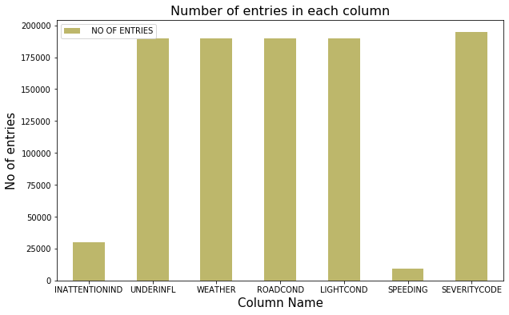

```python
df.describe(include='all')
df2=df.describe(include='all').iloc[0,:].transpose().to_frame()
df2.rename(columns={"count":"  NO OF ENTRIES"}, inplace=True)
df2

colors=random.choices(  list(mpl.colors.CSS4_COLORS.values()), k=7   )
df2.plot(kind='bar', figsize=(10,6),color=colors)

plt.title('Number of entries in each column', fontsize=16)
plt.xlabel("Column Name",fontsize=15)
plt.ylabel("No of entries",fontsize=15)
plt.xticks(rotation=360)
plt.show()
```

## Balancing the Dataset

```python
def print_sev(df):
    a=df.iloc[:,6].value_counts().to_frame()
    print(a)
    colors=['#5cb85c' , '#5bc0de']
    ax=a.plot(kind='bar', figsize=(6, 4), width=0.8)
    plt.title('Type of accidents in Seattle', fontsize=16)
    plt.xlabel("SEVERITY TYPE")
    plt.ylabel("Frequency",fontsize=15)
    plt.xticks(rotation=360)
    plt.show()
```

Number of entries in SEVERITYCODE is given as follows

```
   SEVERITYCODE
1        136485
2         58188
```

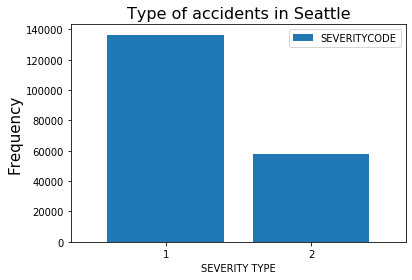

```python
print_sev(df)
```

```
   SEVERITYCODE
2         58188
1         58188
```

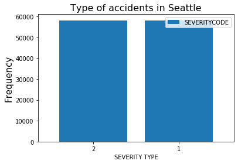

```python
df_maj=df[df.SEVERITYCODE==1]
df_min=df[df.SEVERITYCODE==2]
df_maj_sample=resample(df_maj, replace=False,n_samples=58188, random_state=123)
df=pd.concat([df_maj_sample, df_min])

print_sev(df)
```

## Converting Categorical features to Numerical values:

We will now investigate each column, we will replace the categorial value of each feature by numerical value depending on the accident severity.For this conversion, we cant just depend on the values inserted in the columns. For example, in weather column, the weather condition "Clear" appears the most, but it does not mean that the clear weather result in most severe accidents. Most of the days in the year are clear, thats why it results in highest number of entries in weather column. SO we will see how many accidents will result in physical injusy. We will categorize each column into different groups and assign a number to each group depending on the ration of physical injury to total number of accidents.

```python
def column_stat(n):
    c=df.columns[n]

    number_null=df.iloc[:,n].isnull().sum()
    print('Number of Null entries: ', number_null,'\n')

    df.iloc[:,n].fillna("Null Entry", inplace=True)

    gr=df.groupby([c,'SEVERITYCODE']).size().reset_index()
    s=gr.pivot(index=c, columns='SEVERITYCODE')
    s.columns=['Property Damage ','Physical Injury']

    print(s)
    injury_per=s.iloc[:,1]*100/(s.iloc[:,0]+s.iloc[:,1])

    colors=['#5cb85c' , '#5bc0de']
    ax=s.plot(kind='bar', figsize=(6,4), width=0.8 , color=colors)
    plt.title(c, fontsize=16)
    plt.legend(fontsize=14)
    plt.xticks(fontsize=14)
    plt.show()

    colors=['#5cb75c']
    ax2=injury_per.plot(kind='bar', figsize=(6,4), width=0.8 , color=colors)
    plt.title("% of Physical Injury to total Physical injury+Property damage:", fontsize=16)
    plt.xticks(fontsize=14)
    plt.show()
```

### Column SEVERITYCODE

```python
a=df.iloc[:,6].value_counts().to_frame()
print(a,'\n')

number_null=df.iloc[:,6].isnull().sum()
print('Number of Null entries: ', number_null,'\n')
```

```
   SEVERITYCODE
2         58188
1         58188

Number of Null entries:  0
```

The column SEVERITYTYPE does not need to change, there is no null value. We will use this severity code as the label of out model.

### Column INATTENTIONIND

```
Number of Null entries:  97717

                Property Damage   Physical Injury
INATTENTIONIND
Null Entry                 49926            47791
Y                           8262            10397
```

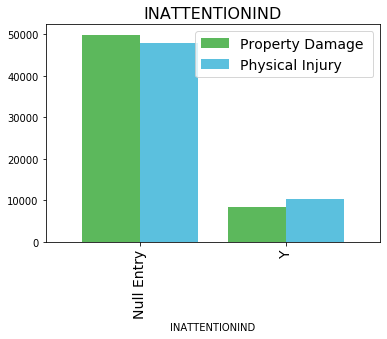

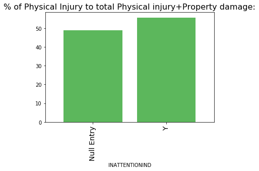

```python
column_stat(0)
```

There are 97717 null entries in the column INATTENTIONIND. We can assume blank cell/ null entry means there was no such condition. Lets replace null values by 0 and 'Y' by 1.

```python
df.iloc[:,0].replace('Null Entry', 0, inplace=True)
df.iloc[:,0].replace('Y', 1, inplace=True)

a=df.iloc[:,0].value_counts().to_frame()
print(a,'\n')
```

```
   INATTENTIONIND
0           97717
1           18659
```

### Column UNDERINFL

```
Number of Null entries:  2693

            Property Damage   Physical Injury
UNDERINFL
0                      24762            22701
1                       1025             1623
N                      29336            30896
Null Entry              1664             1029
Y                       1401             1939
```

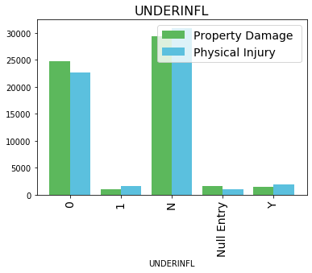

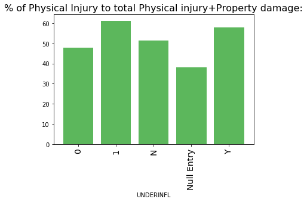

```python
column_stat(1)
```

There are 2693 null entries in the column UNDERINFL, lets replace null values by 0, 'Y' by 1, 'N' by 0

```python
df.iloc[:,1].replace(['Null Entry','0', 'N'], 0, inplace=True)
df.iloc[:,1].replace(['Y', '1'], 1, inplace=True)


a=df.iloc[:,1].value_counts().to_frame()
print(a,'\n')
```

```
   UNDERINFL
0     110388
1       5988
```

### Column WEATHER

```
Number of Null entries:  2816

                          Property Damage   Physical Injury
WEATHER
Blowing Sand/Dirt                       15               15
Clear                                32106            35840
Fog/Smog/Smoke                         168              187
Null Entry                            1732             1084
Other                                  290              116
Overcast                              8089             8745
Partly Cloudy                            1                3
Raining                               9408            11176
Severe Crosswind                         6                7
Sleet/Hail/Freezing Rain                35               28
Snowing                                303              171
Unknown                               6035              816
```

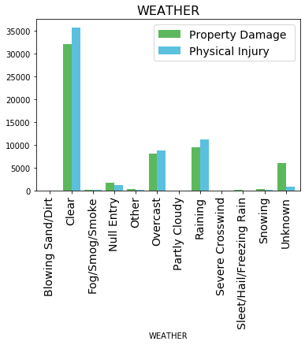

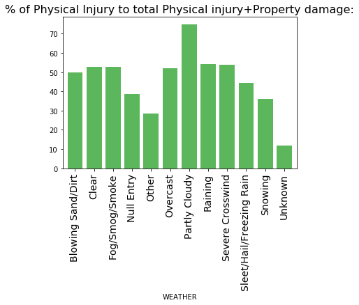

```python
column_stat(2)
```

There are 2816 null entries in the column WEATHER. From the above graph we can categorize the weather condition into 9 different groups and assign a point in the range 0-8.

```python
df.iloc[:,2].replace("Unknown",0, inplace=True)
df.iloc[:,2].replace("Other" ,1, inplace=True)
df.iloc[:,2].replace("Null Entry", 2, inplace=True)
df.iloc[:,2].replace("Snowing", 3, inplace=True)
df.iloc[:,2].replace(["Blowing Sand/Dirt", "Sleet/Hail/Freezing Rain"], 4, inplace=True)
df.iloc[:,2].replace(["Overcast", "Severe Crosswind"], 5, inplace=True)
df.iloc[:,2].replace( ["Raining", "Fog/Smog/Smoke"], 6, inplace=True)
df.iloc[:,2].replace("Clear", 7, inplace=True)
df.iloc[:,2].replace( "Partly Cloudy", 8, inplace=True)


a=df.iloc[:,2].value_counts().to_frame()
print(a,'\n')
```

```
   WEATHER
7    67946
6    20939
5    16847
0     6851
2     2816
3      474
1      406
4       93
8        4
```

### Column ROADCOND

```
Number of Null entries:  2764

                Property Damage   Physical Injury
ROADCOND
Dry                        35936            40064
Ice                          405              273
Null Entry                  1704             1060
Oil                           15               24
Other                         40               43
Sand/Mud/Dirt                 24               23
Snow/Slush                   361              167
Standing Water                27               30
Unknown                     6057              749
Wet                        13619            15755
```

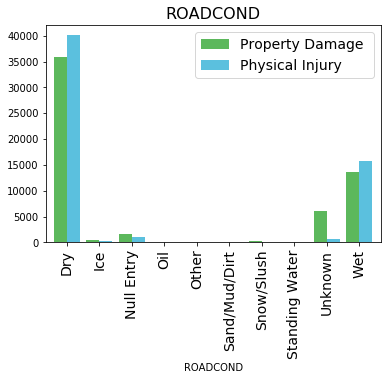

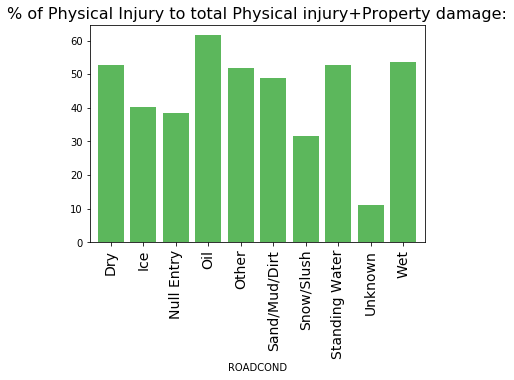

```python
column_stat(3)
```

There are 2764 null entries in the column ROADCOND. From the above graph we can categorize the weather condition into 9 different groups and assign a point in the range 0-8.

```python
df.iloc[:,3].replace( "Unknown", 0, inplace=True)
df.iloc[:,3].replace( "Null Entry", 1, inplace=True)
df.iloc[:,3].replace( "Other", 2, inplace=True)
df.iloc[:,3].replace( "Snow/Slush", 3, inplace=True)
df.iloc[:,3].replace("Ice", 4, inplace=True)
df.iloc[:,3].replace("Sand/Mud/Dirt" , 5, inplace=True)
df.iloc[:,3].replace("Dry", 6, inplace=True)
df.iloc[:,3].replace(["Standing Water", "Wet"], 7, inplace=True)
df.iloc[:,3].replace("Oil", 8, inplace=True)

a=df.iloc[:,3].value_counts().to_frame()
print(a,'\n')
```

```
   ROADCOND
6     76000
7     29431
0      6806
1      2764
4       678
3       528
2        83
5        47
8        39
```

### Column LIGHTCOND

```
Number of Null entries:  2848

                          Property Damage   Physical Injury
LIGHTCOND
Dark - No Street Lights                532              334
Dark - Street Lights Off               387              316
Dark - Street Lights On              14658            14475
Dark - Unknown Lighting                  3                4
Dawn                                   711              824
Daylight                             32959            38544
Dusk                                  1648             1944
Null Entry                            1758             1090
Other                                   75               52
Unknown                               5457              605
```

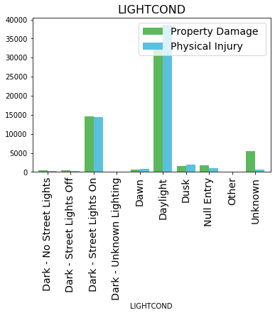

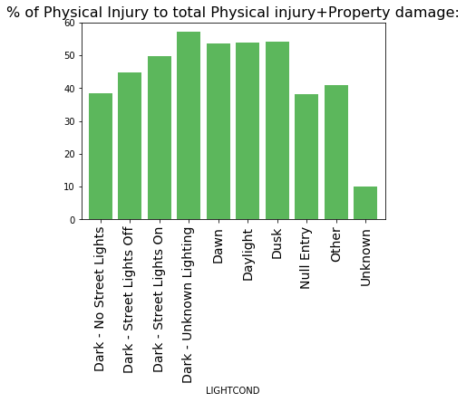

```python
column_stat(4)
```

There are 2848 null entries in the column LIGHTCOND. From the above graph we can categorize the light condition into 7 different groups and assign a point in the range 0-6.

```python
df.iloc[:,4].replace( "Unknown", 0, inplace=True)
df.iloc[:,4].replace(["Null Entry", "Other"], 1, inplace=True)
df.iloc[:,4].replace("Dark - No Street Lights", 2, inplace=True)
df.iloc[:,4].replace( "Dark - Street Lights Off", 3, inplace=True)
df.iloc[:,4].replace("Dark - Street Lights On", 4, inplace=True)
df.iloc[:,4].replace(["Daylight", "Dusk", "Dawn"], 5, inplace=True)
df.iloc[:,4].replace("Dark - Unknown Lighting", 6, inplace=True)


a=df.iloc[:,4].value_counts().to_frame()
print(a,'\n')
```

```
   LIGHTCOND
5      76630
4      29133
0       6062
1       2975
2        866
3        703
6          7
```

### Column SPEEDING

```
Number of Null entries:  110396

            Property Damage   Physical Injury
SPEEDING
Null Entry             55739            54657
Y                       2449             3531
```

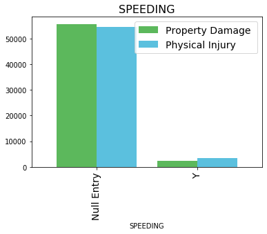

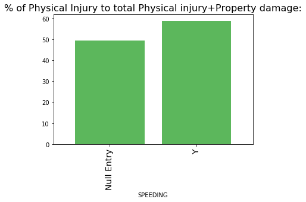

```python
column_stat(5)
```

There are 110396 null entries in the column SPEEDING. We can assume blank cell/ null entry means there was no such condition. Lets replace null values by 0 and 'Y' by 1.

```python
df.iloc[:,5].replace('Null Entry', 0, inplace=True)
df.iloc[:,5].replace('Y', 1, inplace=True)


a=df.iloc[:,5].value_counts().to_frame()
print(a,'\n')
```

```
   SPEEDING
0    110396
1      5980
```

### Correlation between diffeternt columns

```python
df.corr()
```

|  | INATTENTIONIND | UNDERINFL | WEATHER | ROADCOND | LIGHTCOND | SPEEDING | SEVERITYCODE |
| --- | --- | --- | --- | --- | --- | --- | --- |
| INATTENTIONIND | 1.000000 | -0.033188 | 0.096425 | 0.085185 | 0.107399 | -0.051636 | 0.050000 |
| UNDERINFL | -0.033188 | 1.000000 | 0.059519 | 0.065540 | -0.032940 | 0.100824 | 0.044185 |
| WEATHER | 0.096425 | 0.059519 | 1.000000 | 0.756772 | 0.657270 | 0.027109 | 0.179374 |
| ROADCOND | 0.085185 | 0.065540 | 0.756772 | 1.000000 | 0.666291 | 0.070574 | 0.189786 |
| LIGHTCOND | 0.107399 | -0.032940 | 0.657270 | 0.666291 | 1.000000 | 0.021356 | 0.187863 |
| SPEEDING | -0.051636 | 0.100824 | 0.027109 | 0.070574 | 0.021356 | 1.000000 | 0.042111 |
| SEVERITYCODE | 0.050000 | 0.044185 | 0.179374 | 0.189786 | 0.187863 | 0.042111 | 1.000000 |

From the correlation table, we can see that, there is a strong relation between Weather, Road Condition and Light Condition

### Feature Selection

The following columns will be used as features in our model.

```python
X=df[[ 'INATTENTIONIND', 'UNDERINFL', 'WEATHER', 'ROADCOND',  'LIGHTCOND', 'SPEEDING']]
y=df['SEVERITYCODE']

X[0:5]
```

|  | INATTENTIONIND | UNDERINFL | WEATHER | ROADCOND | LIGHTCOND | SPEEDING |
| --- | --- | --- | --- | --- | --- | --- |
| 25055 | 0 | 0 | 6 | 7 | 4 | 0 |
| 65280 | 0 | 0 | 7 | 6 | 5 | 0 |
| 86292 | 0 | 0 | 0 | 0 | 0 | 0 |
| 155111 | 0 | 0 | 7 | 6 | 5 | 0 |
| 64598 | 0 | 0 | 7 | 6 | 5 | 0 |

### Label Selection

The column SEVERITYCODE will be used as our label. SO there will be 2 labels: label 1 and label 2.

### Normalize Data

We will normalize the features before developing the model. The first 5 rows of normalized featured data is as follows-

```python
X= preprocessing.StandardScaler().fit_transform(X)
X[0:5]
```

```
array([[-0.43697754, -0.23290562,  0.02297305,  0.72225251, -0.27587799,
        -0.23274155],
       [-0.43697754, -0.23290562,  0.56847646,  0.14194529,  0.50649789,
        -0.23274155],
       [-0.43697754, -0.23290562, -3.25004737, -3.33989801, -3.40538151,
        -0.23274155],
       [-0.43697754, -0.23290562,  0.56847646,  0.14194529,  0.50649789,
        -0.23274155],
       [-0.43697754, -0.23290562,  0.56847646,  0.14194529,  0.50649789,
        -0.23274155]])
```

### Dividing data into training set and test set

In order to develop a model for predicting accident severity, the resampled, cleaned dataset was split in to testing and training sub-samples (containing 30% and 70% of the samples, respectively) using the scikit learn “train_test_split” method.

```python
x_train, x_test, y_train, y_test= train_test_split(X, y, test_size=0.3 , random_state=2)
```

# Machine Learning Models: Classification

We will use the training set to build an accurate model. Then use the test set to report the accuracy of the model.

We will use the following algorithm:

- K Nearest Neighbor(KNN)
- Decision Tree
- Logistic Regression

Support Vector Machine will not be used as this algorithm is ussed for small dataset.

## K Nearest Neighbor(KNN)

KNN will help us predict the severity code of an outcome by finding the most similar to data point within k distance.

We will first find the best k to build the model with the best accuracy.

```python
for  k in range(12,19):
    clf=KNeighborsClassifier(n_neighbors=k)
    clf.fit(x_train, y_train)
    y_pred= clf.predict(x_test)
    print("K= ", k ," ,Accuracy Score= " , accuracy_score(y_test, y_pred),", F1 Score= " , f1_score(y_test, y_pred, average='weighted'))
```

```
K=  12  ,Accuracy Score=  0.5191762380775069 , F1 Score=  0.4667196901947999
K=  13  ,Accuracy Score=  0.5359035316357804 , F1 Score=  0.5333447086160248
K=  14  ,Accuracy Score=  0.5166843296193395 , F1 Score=  0.4676649660358987
K=  15  ,Accuracy Score=  0.522470140062441 , F1 Score=  0.49584148775223524
K=  16  ,Accuracy Score=  0.5220691432990576 , F1 Score=  0.4765245571776488
K=  17  ,Accuracy Score=  0.515853693466617 , F1 Score=  0.5088676541335826
K=  18  ,Accuracy Score=  0.5249906911465643 , F1 Score=  0.4962442609245468
```

We can see that for *k=13*, KNeighborsClassifier is giving the best F1 score. Lets build the KNN model with k=13

```python
best_knn=KNeighborsClassifier(n_neighbors=13)
best_knn.fit(x_train, y_train)
y_pred= best_knn.predict(x_test)
print("For K=", 13 ,", Accuracy Score=" , accuracy_score(y_test, y_pred), ", Jaccard Score=", jaccard_similarity_score(y_test, y_pred), ", F1 Score= ", f1_score(y_test, y_pred, average='weighted'))
```

```
For K= 13 , Accuracy Score= 0.5359035316357804 , Jaccard Score= 0.5359035316357804 , F1 Score=  0.5333447086160248
```

## Decision Tree

A decision tree model gives us a layout of all possible outcomes so we can fully analyze the concequences of a decision. It context, the decision tree observes all possible outcomes of different weather conditions.

```python
for  k in range(1,11):
    clf=DecisionTreeClassifier(criterion="entropy", max_depth=k)
    clf.fit(x_train, y_train)
    y_pred= clf.predict(x_test)
    print("Max Depth= ", k, ", Accuracy Score= " , accuracy_score(y_test, y_pred),", F1 Score= " , f1_score(y_test, y_pred, average='weighted'))
```

```
Max Depth=  1 , Accuracy Score=  0.5451550998195515 , F1 Score=  0.4359419322700957
Max Depth=  2 , Accuracy Score=  0.5587030618967147 , F1 Score=  0.4754656341244437
Max Depth=  3 , Accuracy Score=  0.5586744192707588 , F1 Score=  0.47538895933312886
Max Depth=  4 , Accuracy Score=  0.5670380660498955 , F1 Score=  0.5520076852738023
Max Depth=  5 , Accuracy Score=  0.5703606106607854 , F1 Score=  0.5494107069975682
Max Depth=  6 , Accuracy Score=  0.5705038237905651 , F1 Score=  0.5511519243168462
Max Depth=  7 , Accuracy Score=  0.5714776730730673 , F1 Score=  0.534849820934144
Max Depth=  8 , Accuracy Score=  0.5724515223555695 , F1 Score=  0.5376757179851738
Max Depth=  9 , Accuracy Score=  0.5726520207372612 , F1 Score=  0.5408474598884503
Max Depth=  10 , Accuracy Score=  0.5729670896227766 , F1 Score=  0.5406561558634732
```

```python
best_tree=DecisionTreeClassifier(criterion="entropy", max_depth=6)
best_tree.fit(x_train, y_train)
y_pred= best_tree.predict(x_test)
print("For Maximum Depth=", 6 ,", Accuracy Score=" , accuracy_score(y_test, y_pred), ", Jaccard Score=", jaccard_similarity_score(y_test, y_pred), ", F1 Score= ", f1_score(y_test, y_pred, average='weighted'))
```

```
For Maximum Depth= 6 , Accuracy Score= 0.5705038237905651 , Jaccard Score= 0.5705038237905651 , F1 Score=  0.5511519243168462
```

## Logistic Regression

Because our dataset only provides us with two severity code outcomes, our model will only predict one of those two classes. This makes our data binary, which is perfect to use with logistic regression.

```python
for  k in ('lbfgs', 'saga', 'liblinear', 'newton-cg', 'sag'):
    clf=LogisticRegression(C=0.01, solver=k)
    clf.fit(x_train, y_train)
    y_pred= clf.predict(x_test)
    y_pred2= clf.predict_proba(x_test)
    print("For solver:", k ,", Log loss= " , log_loss(y_test, y_pred2),", F1 Score= " , f1_score(y_test, y_pred, average='weighted'))
```

```
For solver: lbfgs , Log loss=  0.6664525059380347 , F1 Score=  0.5492367655690457
For solver: saga , Log loss=  0.6664524287358007 , F1 Score=  0.5492367655690457
For solver: liblinear , Log loss=  0.6664528829319477 , F1 Score=  0.5492367655690457
For solver: newton-cg , Log loss=  0.6664524759351989 , F1 Score=  0.5492367655690457
For solver: sag , Log loss=  0.666452547454923 , F1 Score=  0.5492367655690457
```

We can see that for all solvers, logistic regression is giving the same result. We will choose *liblinear* method for logistic regression. Lets see the effect of regularization on this model.

```python
for  c in (0.001, 0.01, 0.1):
    clf=LogisticRegression(C=c, solver='liblinear')
    clf.fit(x_train, y_train)
    y_pred= clf.predict(x_test)
    y_pred2= clf.predict_proba(x_test)
    print("For regularization:", c ,", Log loss= " , log_loss(y_test, y_pred2),", F1 Score= " , f1_score(y_test, y_pred, average='weighted'))
```

```
For regularization: 0.001 , Log loss=  0.666559065215783 , F1 Score=  0.5491034805500915
For regularization: 0.01 , Log loss=  0.6664528829319477 , F1 Score=  0.5492367655690457
For regularization: 0.1 , Log loss=  0.6664443445515155 , F1 Score=  0.5492367655690457
```

```python
best_lr=LogisticRegression(C=0.001, solver='liblinear')
best_lr.fit(x_train, y_train)
y_pred= best_lr.predict(x_test)
print("For liblinear: Accuracy Score= " , accuracy_score(y_test, y_pred), ", Jaccard Score=", jaccard_similarity_score(y_test, y_pred), ", F1 Score= ", f1_score(y_test, y_pred, average='weighted'))
```

```
For liblinear: Accuracy Score=  0.5709334631799043 , Jaccard Score= 0.5709334631799043 , F1 Score=  0.5491034805500915
```

```python
J_list=[]
F_list=[]
L_list=[]

# KNN
y_pred=best_knn.predict(x_test)
J1=jaccard_similarity_score(y_test, y_pred)
F1= f1_score(y_test, y_pred, average='weighted')
L1='NA'
J_list.append(J1)
F_list.append(F1)
L_list.append(L1)

# Decision Tree Classifier
y_pred=best_tree.predict(x_test)
J2=jaccard_similarity_score(y_test, y_pred)
F2= f1_score(y_test, y_pred, average='weighted')
L2='NA'
J_list.append(J2)
F_list.append(F2)
L_list.append(L2)


# Logistic Regression
y_pred=best_lr.predict(x_test)
J3=jaccard_similarity_score(y_test, y_pred)
F3= f1_score(y_test, y_pred, average='weighted')
L3=log_loss(y_test, best_lr.predict_proba(x_test))
J_list.append(J3)
F_list.append(F3)
L_list.append(round(L3,2))
```

# Results

```python
columns = ['KNN', 'Decision Tree', 'Logistic Regression']
index = ['Jaccard', 'F1-score', 'Logloss']

J_list =  [round(x,2) for x in J_list]
F_list =  [round(x,2) for x in F_list]


accuracy_df = pd.DataFrame([J_list, F_list, L_list], index = index, columns = columns)
accuracy_df=accuracy_df.transpose()
accuracy_df.columns.name = 'Algorithm'

accuracy_df
```

| Algorithm | Jaccard | F1-score | Logloss |
| --- | --- | --- | --- |
| KNN | 0.54 | 0.53 | NA |
| Decision Tree | 0.57 | 0.55 | NA |
| Logistic Regression | 0.57 | 0.55 | 0.67 |

```python
def plot_confusion_matrix(cm, classes,
                          normalize=False,
                          title='Confusion matrix',
                          cmap=plt.cm.Blues):
    """
    This function prints and plots the confusion matrix.
    Normalization can be applied by setting `normalize=True`.
    """
    if normalize:
        cm = cm.astype('float') / cm.sum(axis=1)[:, np.newaxis]
        print("Normalized confusion matrix")
    else:
        print('Confusion matrix, without normalization')



    plt.imshow(cm, interpolation='nearest', cmap=cmap)
    plt.title(title)
    plt.colorbar()
    tick_marks = np.arange(len(classes))
    plt.xticks(tick_marks, classes, rotation=45)
    plt.yticks(tick_marks, classes)

    fmt = '.2f' if normalize else 'd'
    thresh = cm.max() / 2.
    for i, j in itertools.product(range(cm.shape[0]), range(cm.shape[1])):
        plt.text(j, i, format(cm[i, j], fmt),
                 horizontalalignment="center",
                 color="white" if cm[i, j] > thresh else "black")

    plt.tight_layout()
    plt.ylabel('True label')
    plt.xlabel('Predicted label')
```

```
(34913,)
(34913,)
Confusion matrix, without normalization
```

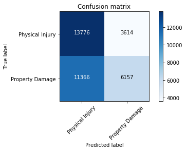

```python
# Compute confusion matrix
print(y_test.shape)
print(y_test.shape)
cnf_matrix = confusion_matrix(y_test, y_pred, labels=[2,1])
np.set_printoptions(precision=2)


# Plot non-normalized confusion matrix
plt.figure()
plot_confusion_matrix(cnf_matrix, classes=['Physical Injury','Property Damage'], normalize= False,  title='Confusion matrix')
```

The above classification report shows that total number of physical injury is 17390 where the model identified 13776 such cases. Total number of property damage is 17523 where the model identified only 6157 cases correctly.

### Classification report

```python
print(classification_report(y_test, y_pred))
```

```
              precision    recall  f1-score   support

           1       0.63      0.35      0.45     17523
           2       0.55      0.79      0.65     17390

    accuracy                           0.57     34913
   macro avg       0.59      0.57      0.55     34913
weighted avg       0.59      0.57      0.55     34913
```

The precision, recall and f1 score for label 2 or Actual Phycal injury is good enough but both recall score and f1 score for the label 1 or Physical damage is very poor. That is why the average f1 score is not as high as expected even for a the logistic regression. We can conclude that, more datas are required to improve this model.

# Discussions

Once we analyzed and cleaned the data, it was then fed through three ML models; K-Nearest Neighbor, Decision Tree and Logistic Regression. Although the first two are ideal for this project, logistic regression made most sense because of its binary nature.

Evaluation metrics used to test the accuracy of our models were jaccard index, f-1 score and logloss for logistic regression. Choosing different k, max depth and hyparameter C values helped to improve our accuracy to be the best possible.

# Recommendations

After assessing the data and the output of the Machine Learning models, a few recommendations can be made for the stakeholders. The developmental body for Seattle city can assess how much of these accidents have occurred in a place where road or light conditions were not ideal for that specific area and could launch development projects for those areas where most severe accidents take place in order to minimize the effects of these two factors. Whereas, the car drivers could also use this data to assess when to take extra precautions on the road under the given circumstances of light condition, road condition and weather, in order to avoid a severe accident, if any.

## Public Development Authority of Seattle (PDAS)

```python
a=df_new.iloc[:,8].value_counts()

a.to_frame()

color_list=['peachpuff','lightseagreen','darkorange']

a.plot(kind='pie',
            figsize=(15, 6),
            autopct='%1.1f%%',
            startangle=90,
            shadow=True,
            labels=a.index,
            colors=color_list)


plt.title('Area of accidents - Seattle, Washington', fontsize=18, y=1.05)
plt.legend(labels=a.index, loc='upper left')

plt.show()
```

[output not shown]

1. Launch development projects for those areas where most severe accidents take place in order to minimize the effects of these two factors
2. Increased investment towards improving lighting and road conditions of the area which have high instances recorded
3. Install safety signs on the roads and ensure that all precautions are being taken by people within the area

## Car Drivers

```python
df_new.iloc[:,0].replace(1, 'Property Damage', inplace=True)
df_new.iloc[:,0].replace(2, 'Physical Injury', inplace=True)

df_new.iloc[:,1].fillna(0, inplace=True)  #Column X
df_new.iloc[:,2].fillna(0, inplace=True)  #Column Y

indexNames = df_new[df_new['X'] == 0].index
df_new.drop(indexNames , inplace=True)

indexNames = df_new[df_new['Y'] == 0].index
df_new.drop(indexNames , inplace=True)

df_new=df_new.iloc[0:df_new.shape[0]:5, 0:]
df_new.dropna(axis=1, how='any', thresh=None, subset=None, inplace=False)

df_new.shape
```

```python
#Folium Map of San Francisco
seattle_map = folium.Map(width=300,height=300, location=[47.61536892, -122.3302243], zoom_start=12)
seattle_map

incidents = plugins.MarkerCluster().add_to(seattle_map)
#incidents=folium.map.FeatureGroup() will show each incident individullay

# loop through the dataframe and add each data point to the mark cluster
for lat, lng, label, in zip(df_new.Y, df_new.X, df_new.iloc[:,0]):
    folium.Marker(
    location=[lat, lng],
    icon=None,
    popup=label,
    ).add_to(incidents)

# add incidents to map
seattle_map.add_child(incidents)

seattle_map
```

[output not shown]